# diamond

```python
import numpy as np # linear algebra
import pandas as pd # data processing, CSV file I/O (e.g. pd.read_csv)
import matplotlib.pyplot as plt
from sklearn.preprocessing import StandardScaler, OneHotEncoder, OrdinalEncoder
from sklearn.model_selection import train_test_split, cross_val_score
from sklearn.linear_model import LinearRegression,Ridge,Lasso,RidgeCV
from sklearn.metrics import mean_squared_error, mean_squared_log_error
import seaborn as sns # Import seaborn for better visualizations
import math
from scipy import stats
from sklearn.ensemble import RandomForestRegressor,BaggingRegressor,GradientBoostingRegressor,AdaBoostRegressor
from sklearn.svm import SVR
from sklearn.neighbors import KNeighborsRegressor
from statsmodels.stats.outliers_influence import variance_inflation_factor
```

```python
from utils import line_plot_viz, box_plot_viz, heat_map_viz, hist_plot_viz, violin_plot_viz, auto_corr_viz
import warnings
warnings.filterwarnings('ignore')
```

Context This classic dataset contains the prices and other attributes of almost 54,000 diamonds. It's a great dataset for beginners learning to work with data analysis and visualization.

Content price price in US dollars ($326--$18,823)

carat weight of the diamond (0.2--5.01)

cut quality of the cut (Fair, Good, Very Good, Premium, Ideal)

color diamond colour, from J (worst) to D (best)

clarity a measurement of how clear the diamond is (I1 (worst), SI2, SI1, VS2, VS1, VVS2, VVS1, IF (best))

x length in mm (0--10.74)

y width in mm (0--58.9)

z depth in mm (0--31.8)

depth total depth percentage = z / mean(x, y) = 2 * z / (x + y) (43--79)

table width of top of diamond relative to widest point (43--95)

```python
og_data = pd.read_csv('./data/Diamonds/diamonds.csv')
data = og_data.copy()
```

```python
data.describe()
```

|  | index | carat | depth | table | price | x | y | z |
| --- | --- | --- | --- | --- | --- | --- | --- | --- |
| count | 53940.000000 | 53940.000000 | 53940.000000 | 53940.000000 | 53940.000000 | 53940.000000 | 53940.000000 | 53940.000000 |
| mean | 26970.500000 | 0.797940 | 61.749405 | 57.457184 | 3932.799722 | 5.731157 | 5.734526 | 3.538734 |
| std | 15571.281097 | 0.474011 | 1.432621 | 2.234491 | 3989.439738 | 1.121761 | 1.142135 | 0.705699 |
| min | 1.000000 | 0.200000 | 43.000000 | 43.000000 | 326.000000 | 0.000000 | 0.000000 | 0.000000 |
| 25% | 13485.750000 | 0.400000 | 61.000000 | 56.000000 | 950.000000 | 4.710000 | 4.720000 | 2.910000 |
| 50% | 26970.500000 | 0.700000 | 61.800000 | 57.000000 | 2401.000000 | 5.700000 | 5.710000 | 3.530000 |
| 75% | 40455.250000 | 1.040000 | 62.500000 | 59.000000 | 5324.250000 | 6.540000 | 6.540000 | 4.040000 |
| max | 53940.000000 | 5.010000 | 79.000000 | 95.000000 | 18823.000000 | 10.740000 | 58.900000 | 31.800000 |

```python
data.info()
```

```
<class 'pandas.core.frame.DataFrame'>
RangeIndex: 53940 entries, 0 to 53939
Data columns (total 11 columns):
 #   Column   Non-Null Count  Dtype
---  ------   --------------  -----
 0   index    53940 non-null  int64
 1   carat    53940 non-null  float64
 2   cut      53940 non-null  object
 3   color    53940 non-null  object
 4   clarity  53940 non-null  object
 5   depth    53940 non-null  float64
 6   table    53940 non-null  float64
 7   price    53940 non-null  int64
 8   x        53940 non-null  float64
 9   y        53940 non-null  float64
 10  z        53940 non-null  float64
dtypes: float64(6), int64(2), object(3)
memory usage: 4.5+ MB
```

```python
data.columns
```

```
Index(['index', 'carat', 'cut', 'color', 'clarity', 'depth', 'table', 'price',
       'x', 'y', 'z'],
      dtype='object')
```

### Check Null/missing Values

```python
data.isnull().sum()
```

```
index      0
carat      0
cut        0
color      0
clarity    0
depth      0
table      0
price      0
x          0
y          0
z          0
dtype: int64
```

## Remove columns

```python
# Drop index column
data = data.drop('index', axis=1)
```

```python
data.dtypes[0]
```

```
dtype('float64')
```

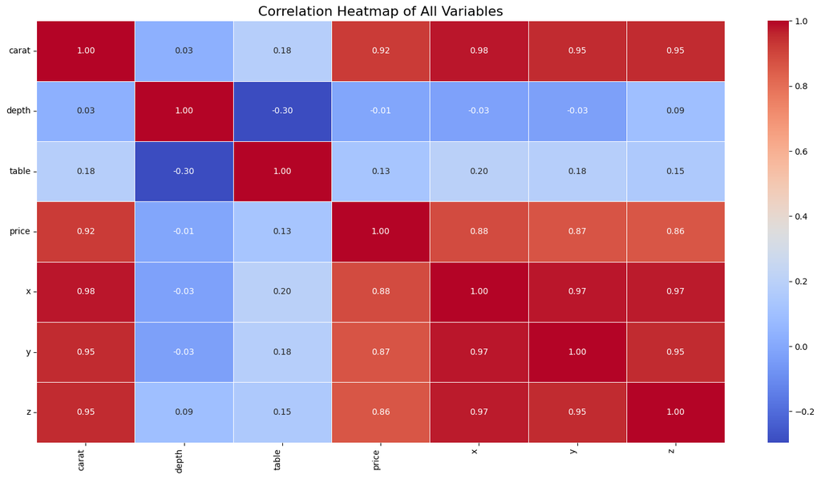

```python
cols= list(data.columns)
numeric_data = data.select_dtypes(include=['float64', 'int64'])
numeric_cols = list(numeric_data.columns)
heat_map_viz(numeric_data)
```

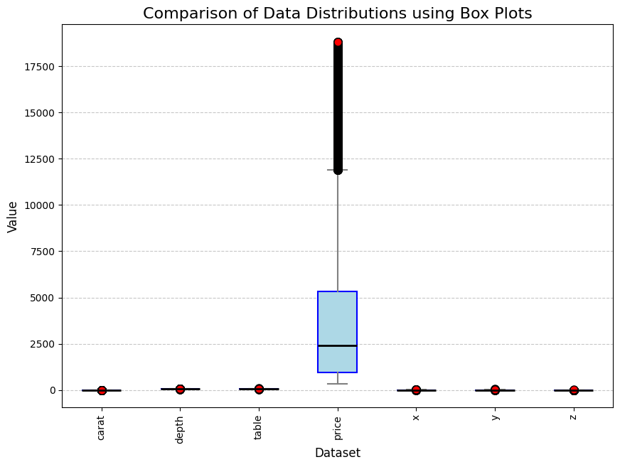

```python
box_plot_viz(numeric_data)
```

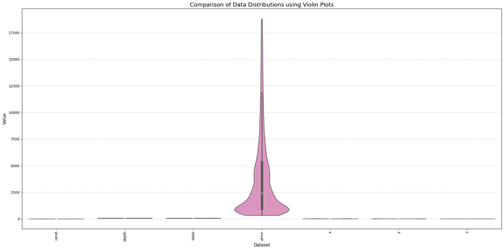

```python
violin_plot_viz(numeric_data)
```

## Scale data for the column price

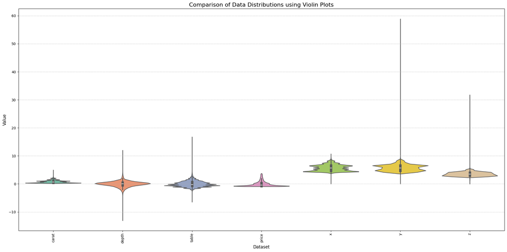

```python
scaler = StandardScaler()
numeric_data['price'] = scaler.fit_transform(numeric_data[['price']])
numeric_data['depth'] = scaler.fit_transform(numeric_data[['depth']])
numeric_data['table'] = scaler.fit_transform(numeric_data[['table']])
violin_plot_viz(numeric_data)
```

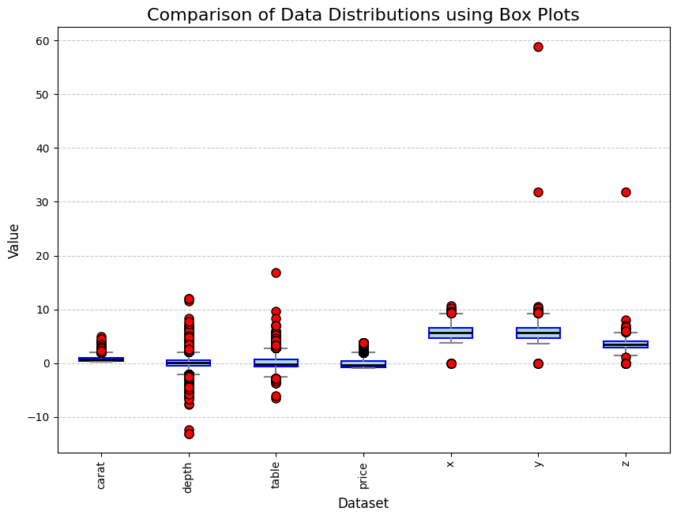

```python
box_plot_viz(numeric_data)
```

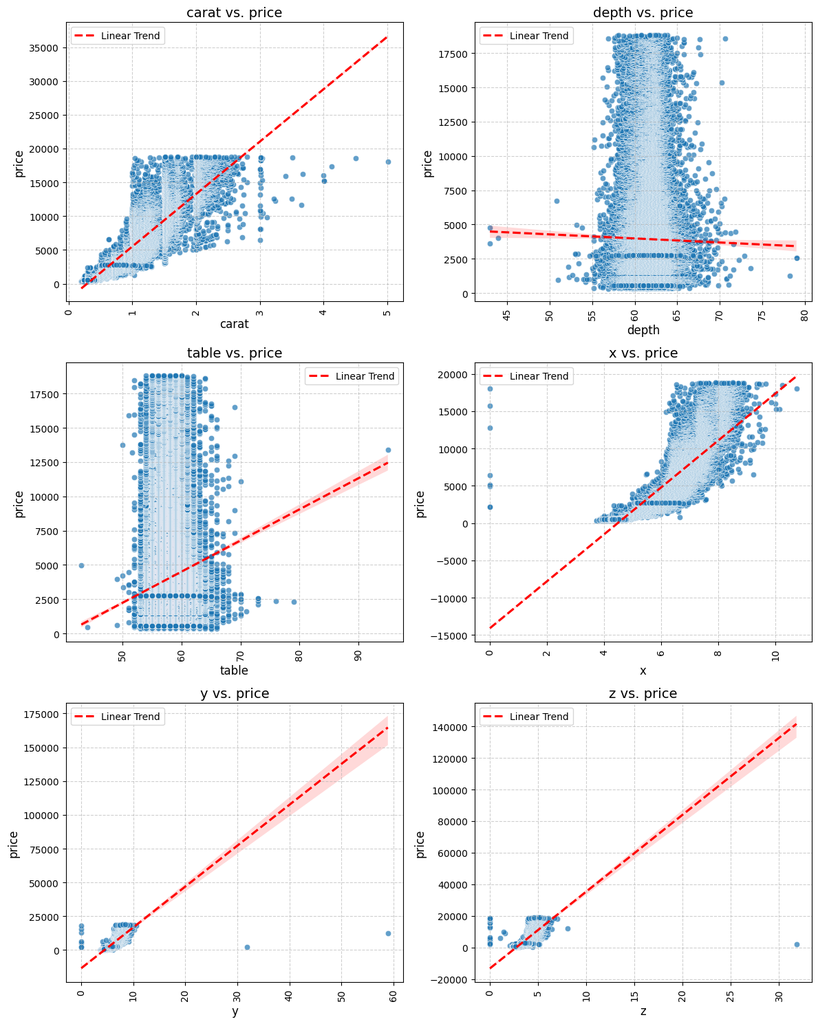

```python
X_cols = ['carat', 'depth', 'table', 'x', 'y', 'z']
Y_cols = ['price']

line_plot_viz(X_columns=X_cols, Y_columns=Y_cols, data=data)
```

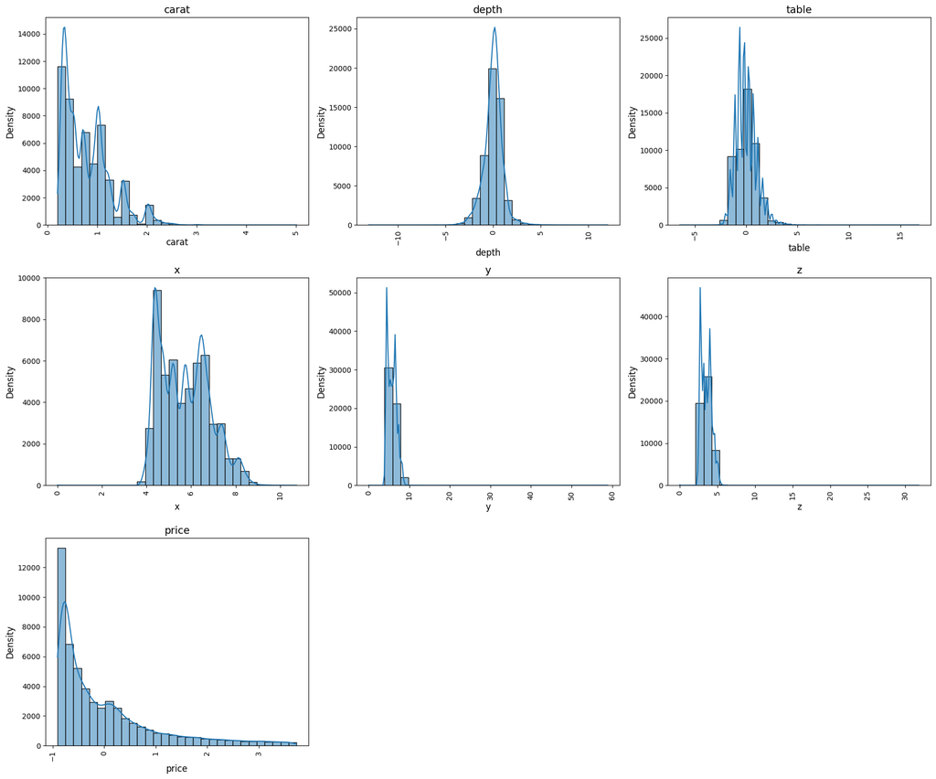

```python
hist_plot_viz(columns=[*X_cols, *Y_cols], data=numeric_data)
```

### VIZ Analysis to test for multi-colinearity

- From the heat map we can see that X, Y, Z and carat have high multicolinearity

```python
# VIF calculation
X_scaled = StandardScaler().fit_transform(data[numeric_cols].drop(['price'], axis = 1))
vif_data = pd.DataFrame()
vif_data['feature'] = data[numeric_cols].drop('price', axis=1).columns
vif_data['VIF'] = [variance_inflation_factor(X_scaled, i) for i in range(X_scaled.shape[1])]
vif_data.sort_values('VIF',ascending=False)
```

|  | feature | VIF |
| --- | --- | --- |
| 3 | x | 56.187704 |
| 5 | z | 23.530049 |
| 0 | carat | 21.602712 |
| 4 | y | 20.454295 |
| 1 | depth | 1.496590 |
| 2 | table | 1.143225 |

```python
# VIF calculation after removing highly multi-colinear features
X_scaled = StandardScaler().fit_transform(data[numeric_cols].drop(['price', 'x', 'y', 'z'], axis = 1))
vif_data = pd.DataFrame()
vif_data['feature'] = data[numeric_cols].drop(['price', 'x', 'y', 'z'], axis = 1).columns
vif_data['VIF'] = [variance_inflation_factor(X_scaled, i) for i in range(X_scaled.shape[1])]
vif_data.sort_values('VIF',ascending=False)
```

|  | feature | VIF |
| --- | --- | --- |
| 2 | table | 1.141032 |
| 1 | depth | 1.104275 |
| 0 | carat | 1.042039 |

### Feature Removal

- Remove x,y,z as they have high multicolinearity with carat

```python
cols_to_remove = ['x', 'y', 'z']
numeric_data.drop(columns= cols_to_remove, inplace=True)
procssd_numeric_cols = [x for x in X_cols if x not in cols_to_remove]
procssd_numeric_cols
```

```
['carat', 'depth', 'table']
```

### Identify the categorical variables

```python
def convert_to_categorical_dtypes(cat_threshold, cols, proc_data):
    data = proc_data.copy()
    for feature in cols:
        uniq_vals = data[feature].unique()
        if(len(uniq_vals) < cat_threshold):
            data[feature] = data[feature].astype('category')
    print(data[cols].dtypes)
    return data
cat_threshold = 30
data = convert_to_categorical_dtypes(cat_threshold=cat_threshold, cols=data.columns, proc_data=data)
```

```
carat       float64
cut        category
color      category
clarity    category
depth       float64
table       float64
price         int64
x           float64
y           float64
z           float64
dtype: object
```

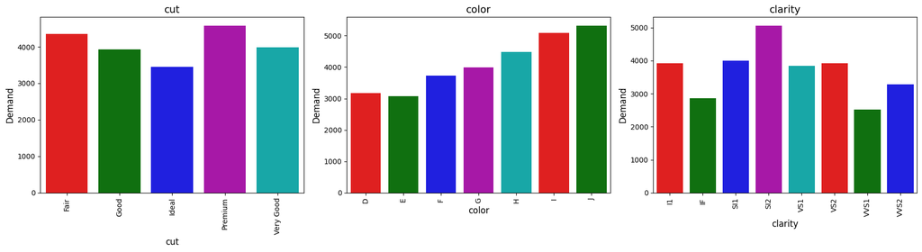

```python
cat_cols = data.select_dtypes(include='category').columns
num_features = len(cat_cols)
n_cols = 3 # You can adjust the number of columns in the grid
n_rows = (num_features + n_cols - 1) // n_cols # Calculate rows needed
colors = ['r', 'g', 'b', 'm', 'c']
fig, axes = plt.subplots(n_rows, n_cols, figsize=(n_cols * 6, n_rows * 5))
axes = axes.flatten() # Flatten the 2D array of axes for easy iteration
i = 0

for feature in cat_cols:
    uniq_vals = data[feature].unique()
    cat_average = data.groupby(feature)[*Y_cols].mean()

    # 3. Iterate through each feature and plot its relationship with the target
    ax = axes[i] # Get the current subplot axis

    sns.barplot(data=cat_average, x= feature, y= 'price',hue=feature, ax=ax, palette=colors)

    ax.set_title(f'{feature}', fontsize=14)
    ax.set_xlabel(feature, fontsize=12)
    ax.set_ylabel('Demand', fontsize=12)
    ax.set_xticklabels(ax.get_xticklabels(), rotation=90)

    i = i + 1
for j in range(i, len(axes)):
        fig.delaxes(axes[j])

plt.tight_layout() # Adjust layout to prevent overlapping titles/labels
plt.show()
```

### Remove columns

- No categorical columns to remove

### Create the processed data by combining the processed numeric and categorical columns

```python
processed_data = pd.concat([data[cat_cols], numeric_data], axis=1)
processed_data.head()
```

|  | cut | color | clarity | carat | depth | table | price |
| --- | --- | --- | --- | --- | --- | --- | --- |
| 0 | Ideal | E | SI2 | 0.23 | -0.174092 | -1.099672 | -0.904095 |
| 1 | Premium | E | SI1 | 0.21 | -1.360738 | 1.585529 | -0.904095 |
| 2 | Good | E | VS1 | 0.23 | -3.385019 | 3.375663 | -0.903844 |
| 3 | Premium | I | VS2 | 0.29 | 0.454133 | 0.242928 | -0.902090 |
| 4 | Good | J | SI2 | 0.31 | 1.082358 | 0.242928 | -0.901839 |

```python
processed_data.dtypes
```

```
cut        category
color      category
clarity    category
carat       float64
depth       float64
table       float64
price       float64
dtype: object
```

### Encode the categorical variables using the below

cut quality of the cut (Fair, Good, Very Good, Premium, Ideal)

color diamond colour, from J (worst) to D (best)

clarity a measurement of how clear the diamond is (I1 (worst), SI2, SI1, VS2, VS1, VVS2, VVS1, IF (best))

```python
encoder = OrdinalEncoder(categories=[['Fair', 'Good', 'Very Good', 'Premium', 'Ideal']])
processed_data['cut'] = encoder.fit_transform(processed_data[['cut']])

encoder = OrdinalEncoder(categories=[['J', 'I', 'H', 'G', 'F', 'E', 'D']])
processed_data['color'] = encoder.fit_transform(processed_data[['color']])

encoder = OrdinalEncoder(categories=[['I1', 'SI2', 'SI1', 'VS2', 'VS1', 'VVS2', 'VVS1', 'IF']])
processed_data['clarity'] = encoder.fit_transform(processed_data[['clarity']])

processed_data.head()
```

|  | cut | color | clarity | carat | depth | table | price |
| --- | --- | --- | --- | --- | --- | --- | --- |
| 0 | 4.0 | 5.0 | 1.0 | 0.23 | -0.174092 | -1.099672 | -0.904095 |
| 1 | 3.0 | 5.0 | 2.0 | 0.21 | -1.360738 | 1.585529 | -0.904095 |
| 2 | 1.0 | 5.0 | 4.0 | 0.23 | -3.385019 | 3.375663 | -0.903844 |
| 3 | 3.0 | 1.0 | 3.0 | 0.29 | 0.454133 | 0.242928 | -0.902090 |
| 4 | 1.0 | 0.0 | 1.0 | 0.31 | 1.082358 | 0.242928 | -0.901839 |

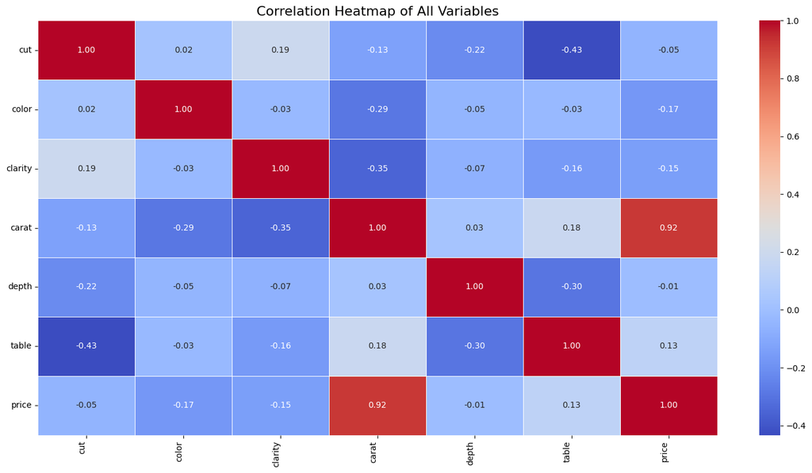

```python
heat_map_viz(processed_data)
```

```python
Y_cols = ['price']
Y = processed_data[Y_cols]
X = processed_data.drop(Y_cols, axis=1)
X_cols = list(X.columns)

print('Target column is: ', Y_cols)
print('Features are: ', X_cols)
```

```
Target column is:  ['price']
Features are:  ['cut', 'color', 'clarity', 'carat', 'depth', 'table']
```

### A look at the distribution of the target variable Price

- According to the plot below the distribution is not normal so let us apply a log normal transform

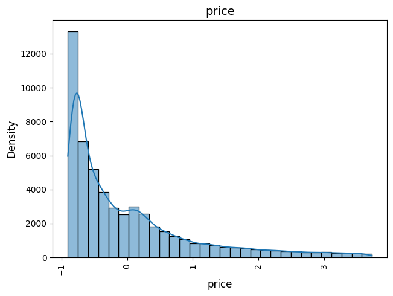

```python
hist_plot_viz(Y_cols, processed_data)
```

#### Below is the graph after the log normal transformation

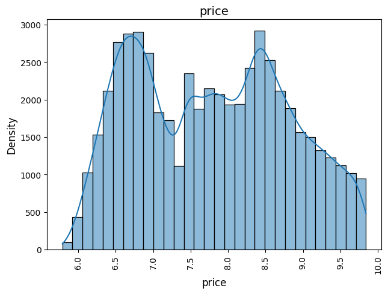

```python
processed_data[Y_cols] = np.log(data[Y_cols])
hist_plot_viz(Y_cols, processed_data)
```

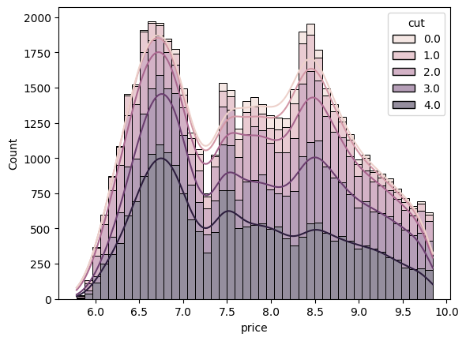

```python
sns.histplot(data=processed_data, x='price', hue='cut', kde=True, multiple='stack')
```

```python
df = processed_data.copy()
df['price_per_carat'] = df['price'] / df['carat']
df.groupby('cut')['price_per_carat'].mean().sort_values()
```

```
cut
0.0     9.226632
1.0    11.575319
3.0    11.755446
2.0    12.499832
4.0    13.902481
Name: price_per_carat, dtype: float64
```

```python
df.groupby('cut')['price'].mean().sort_values()
```

```
cut
4.0    7.639467
2.0    7.798664
1.0    7.842809
3.0    7.950795
0.0    8.093441
Name: price, dtype: float64
```

```python
df = processed_data.copy()
df['price_per_carat'] = df['price'] / df['carat']
df.groupby('color')['price_per_carat'].mean().sort_values()
```

```
color
0.0     8.984839
1.0    10.415987
2.0    11.514335
3.0    12.933443
4.0    13.152478
6.0    14.149139
5.0    14.256642
Name: price_per_carat, dtype: float64
```

```python
df = processed_data.copy()
df['price_per_carat'] = df['price'] / df['carat']
df.groupby('clarity')['price_per_carat'].mean().sort_values()
```

```
clarity
0.0     7.419620
1.0     9.182076
2.0    11.441858
3.0    13.001680
4.0    13.477317
5.0    15.831236
6.0    17.426974
7.0    17.652448
Name: price_per_carat, dtype: float64
```

```python
df['cut'].value_counts().sort_index()
```

```
cut
0.0     1610
1.0     4906
2.0    12082
3.0    13791
4.0    21551
Name: count, dtype: int64
```

## Some important observations from above results

- Though the data legend suggests that there is ordinality in the cut feature ie better cut should be priced higher but if you look at the effect of each type of cut on the price. It does not increase as the cuts get better. Infact I have a hypothesis that the mid quality cuts are overpriced and earn the most margin for the seller. There is enough data for the cut type 2 when compared to the better cuts so imbalance in the classes can also be ruled out.
- We need to remove the ordiality encoding and add one hot encoding.
- All the other categorical variables do show a trend in price due to ordinality so we will preserve that.

```python
cuts_df = pd.get_dummies(data['cut'], drop_first=True, dtype='int')
processed_data = pd.concat([processed_data, cuts_df], axis=1)
```

```python
processed_data.drop('cut', inplace=True, axis=1)
```

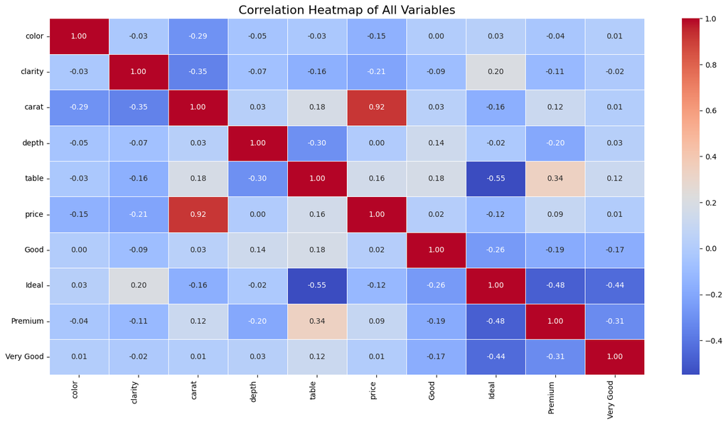

```python
heat_map_viz(processed_data)
```

```python
processed_data.dtypes
```

```
color        float64
clarity      float64
carat        float64
depth        float64
table        float64
price        float64
Good           int64
Ideal          int64
Premium        int64
Very Good      int64
dtype: object
```

### Detect outliers If any

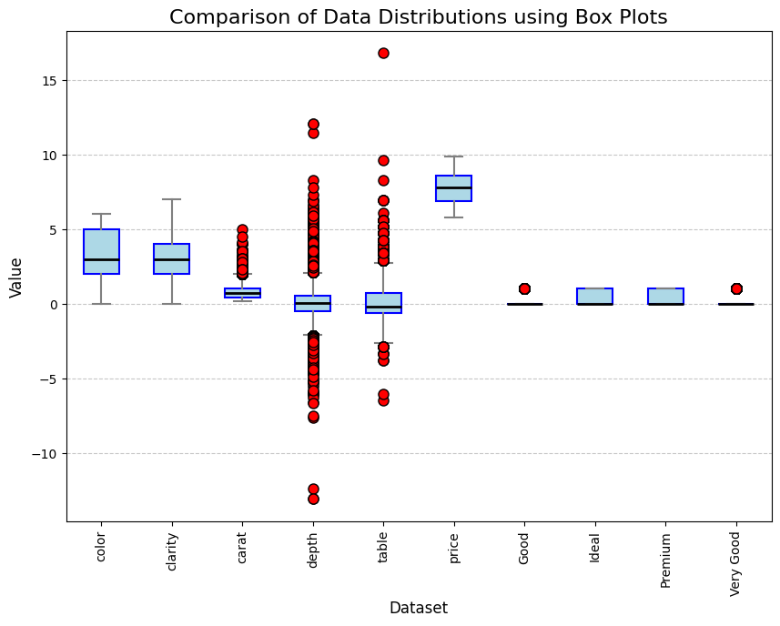

```python
box_plot_viz(processed_data)
```

### Test for autocorrelation in the target column

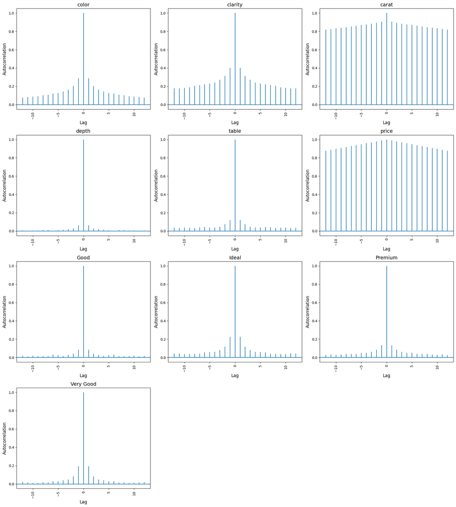

```python
auto_corr_viz(processed_data=processed_data)
```

### Looks like there is high auto corrleation in the features

- lets reshuffle the data and test this again

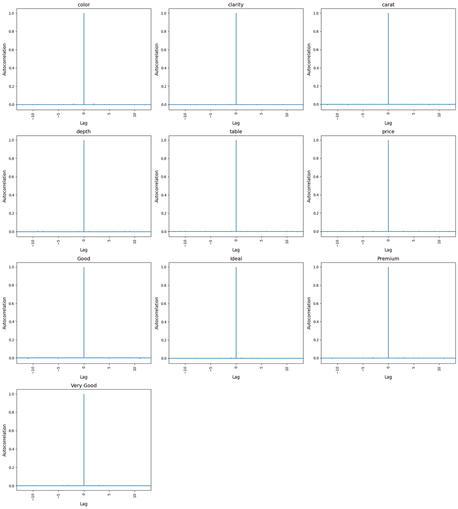

```python
df_shuffled = processed_data.sample(frac=1, random_state=42).reset_index(drop=True)
auto_corr_viz(df_shuffled)
```

#### No auto correlation found

### Train Test Split

```python
X = processed_data.drop(columns=['price'], axis=1)
y = processed_data['price']

X_train, X_test, y_train, y_test = train_test_split(
    X, y, test_size=0.2, random_state=42
)
```

### Fit the linear regression model to get the baseline

```python
model = LinearRegression()
model.fit(X = X_train, y = y_train)
```

```
LinearRegression()
```

#### R Squared metrics of the model

```python
r2_train = model.score(X = X_train, y = y_train)
print('r2 train : ', r2_train)
r2_test = model.score(X = X_test, y = y_test)
print('r2 test : ', r2_test)
```

```
r2 train :  0.8807282361735038
r2 test :  0.8786308335563693
```

```python
# RMSE
y_pred = model.predict(X_test)
rmse = np.sqrt(mean_squared_error(y_test, y_pred))
print(f"RMSE: {rmse:.4f}")
```

```
RMSE: 0.3538
```

```python
rmsle_lin = np.sqrt(mean_squared_log_error(y_test, y_pred))
print(f"RMSLE: {rmsle_lin:.4f}")
```

```
RMSLE: 0.0387
```

### Try other models

```python
models=[RandomForestRegressor(),AdaBoostRegressor(),BaggingRegressor(),SVR(),KNeighborsRegressor()]
model_names=['RandomForestRegressor','AdaBoostRegressor','BaggingRegressor','SVR','KNeighborsRegressor']
rmsle=[]
d={}
for model in range (len(models)):
    clf=models[model]
    clf.fit(X_train,y_train)
    test_pred=clf.predict(X_test)
    rmsle.append(np.sqrt(mean_squared_log_error(y_test, test_pred)))
d={'Modelling Algo':model_names,'RMSLE':rmsle}
```

```python
model_metrics = pd.DataFrame(d)
model_metrics.loc[len(model_metrics)] = {'Modelling Algo':'Linear regression','RMSLE':rmsle_lin}
model_metrics.sort_values(by='RMSLE')
```

|  | Modelling Algo | RMSLE |
| --- | --- | --- |
| 0 | RandomForestRegressor | 0.013249 |
| 2 | BaggingRegressor | 0.013616 |
| 3 | SVR | 0.015268 |
| 1 | AdaBoostRegressor | 0.023683 |
| 5 | Linear regression | 0.038740 |
| 4 | KNeighborsRegressor | 0.040098 |

### Looks like Random forest is our best bet

- Lets do some cross validation to confirm this.

```python
scores = cross_val_score(RandomForestRegressor(), X, y, cv=5, scoring='neg_mean_squared_log_error')
rmsle_scores = np.sqrt(-scores)
print("CV RMSLE:", rmsle_scores.mean(), "+/-", rmsle_scores.std())
```

```
CV RMSLE: 0.02791422699013636 +/- 0.004894436820739914
```

### Lets find the feature importance of the model features

```python
model = RandomForestRegressor().fit(X_train, y_train)
importances = model.feature_importances_
sorted(zip(importances, X.columns), reverse=True)
```

```
[(np.float64(0.942884147192858), 'carat'),
 (np.float64(0.033545345482517704), 'clarity'),
 (np.float64(0.01488669080289693), 'color'),
 (np.float64(0.004459897990771782), 'depth'),
 (np.float64(0.0020440599977183437), 'table'),
 (np.float64(0.0009222934705533204), 'Ideal'),
 (np.float64(0.0005232910510988802), 'Premium'),
 (np.float64(0.000477369391743848), 'Very Good'),
 (np.float64(0.0002569046198413274), 'Good')]
```

#### Carat is the most important and dominant feature.

### Now lets plot the Actuals vs predicted

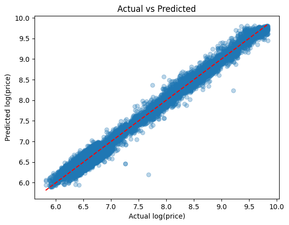

```python
y_pred_rf = model.predict(X_test)
plt.scatter(y_test, model.predict(X_test), alpha=0.3)
plt.xlabel("Actual log(price)")
plt.ylabel("Predicted log(price)")
plt.title("Actual vs Predicted")
min_val = min(y_test.min(), y_pred_rf.min())
max_val = max(y_test.max(), y_pred_rf.max())
plt.plot([min_val, max_val], [min_val, max_val], 'r--', label='Perfect Prediction')
plt.show()
```

### The Residual

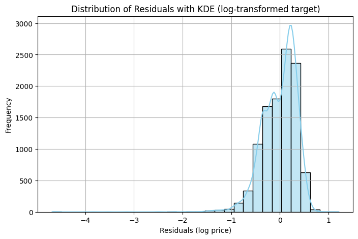

```python
residuals = y_test - y_pred

# Plot
plt.figure(figsize=(8, 5))
sns.histplot(residuals, kde=True, bins=30, color='skyblue', edgecolor='black')
plt.title("Distribution of Residuals with KDE (log-transformed target)")
plt.xlabel("Residuals (log price)")
plt.ylabel("Frequency")
plt.grid(True)
plt.show()
```

# Important! learn about VIF

## Next steps

- Hyper parameter tuning using GridSearchCV or RandomizedSearchCV
- Change train test split and test